# Scatter plots with *many* points

Author

Michael Stadler, Charlotte Soneson

## Summary

This document illustrates how to use `ggplot2` and `scattermore` to:

- make a scatter plot with many data points that shows the density of points without saturation
- that is fast to view and arrange (for example when assembling figure panels)
- that can be stored into a compact file without loss in quality

## Prepare data

Run the following code to prepare the data used in this document:

```r
suppressPackageStartupMessages({
    library(ggplot2)
    library(tibble)
})

# built-in `diamonds` dataset from the `ggplot2` package (see ?ggplot2::diamonds)
tibble(diamonds)
```

```
# A tibble: 53,940 × 10
   carat cut       color clarity depth table price     x     y     z
   <dbl> <ord>     <ord> <ord>   <dbl> <dbl> <int> <dbl> <dbl> <dbl>
 1  0.23 Ideal     E     SI2      61.5    55   326  3.95  3.98  2.43
 2  0.21 Premium   E     SI1      59.8    61   326  3.89  3.84  2.31
 3  0.23 Good      E     VS1      56.9    65   327  4.05  4.07  2.31
 4  0.29 Premium   I     VS2      62.4    58   334  4.2   4.23  2.63
 5  0.31 Good      J     SI2      63.3    58   335  4.34  4.35  2.75
 6  0.24 Very Good J     VVS2     62.8    57   336  3.94  3.96  2.48
 7  0.24 Very Good I     VVS1     62.3    57   336  3.95  3.98  2.47
 8  0.26 Very Good H     SI1      61.9    55   337  4.07  4.11  2.53
 9  0.22 Fair      E     VS2      65.1    61   337  3.87  3.78  2.49
10  0.23 Very Good H     VS1      59.4    61   338  4     4.05  2.39
# ℹ 53,930 more rows
```

## Create figure

### Load packages

```r
library(ggplot2)
library(scattermore)
```

### Plot

Let’s first create a simple scatter plot to illustrate the problems. The `diamonds` dataset has 53940 observations. If stored into a vectorized graphics device such as `pdf()` or `svg()`, the file will be large (each observation is individually represented as graphic elements) and slow to open or arrange. Furthermore, the high number of data points leads to saturation and we do not see the full underlying density of data points.

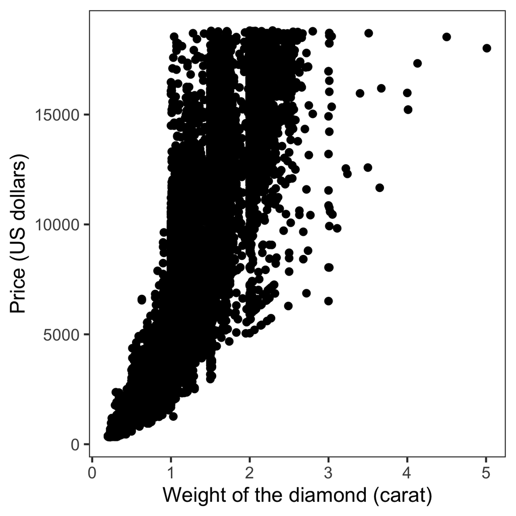

```r
# create base plot
gg <- ggplot(data = diamonds, mapping = aes(x = carat, y = price)) +
    labs(x = "Weight of the diamond (carat)", y = "Price (US dollars)") +
    theme_bw(20) +
    theme(panel.grid = element_blank(),
          legend.position = "bottom")
gg + geom_point()
```

A simple way to improve the saturation issue is to use transparency, so that overlapping observations lead to darker colors. However, this does not solve the “many points” problem yet.

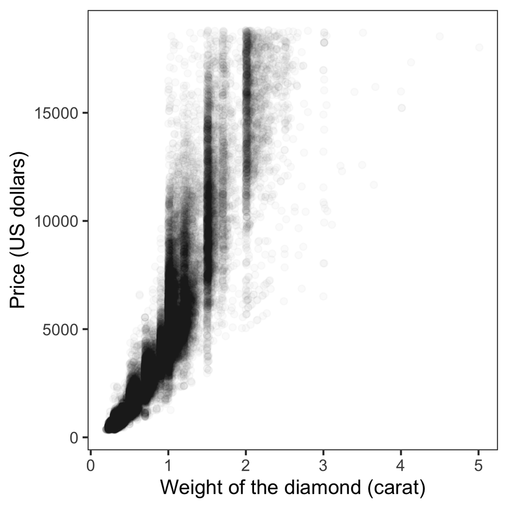

```r
# ... with transparency
gg + geom_point(color = alpha("black", 0.02))
```

A simple way to solve also the “many points” problem is to avoid showing all individual observations and instead show the local density of points using a color scale.

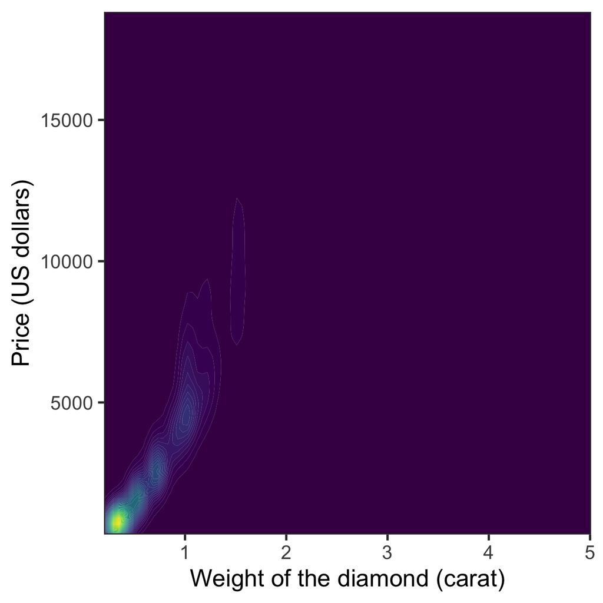

```r
# ... with marginal density plots by number of cylinders
gg + geom_density_2d_filled(bins = 48) +
    coord_cartesian(expand = FALSE) +
    theme(legend.position = "none")
```

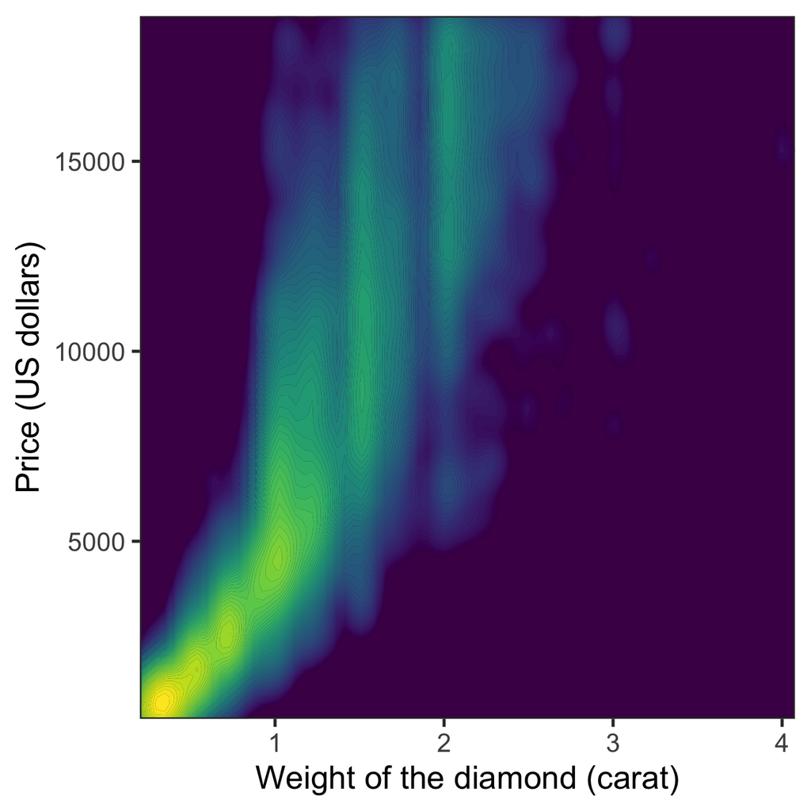

```r
# ... with marginal density plots by number of cylinders
gg + geom_density_2d_filled(contour_var = "ndensity",
                            breaks = exp(seq(log(1e-4), log(1), length.out = 64))) +
    coord_cartesian(expand = FALSE) +
    theme(legend.position = "none",
          panel.background = element_rect(fill = hcl.colors(64)[1]))
```

Finally, if you prefer to show individual observations and need something that will scale to millions of points without getting slow or hard to use, `scattermore` provides a solution for that too.

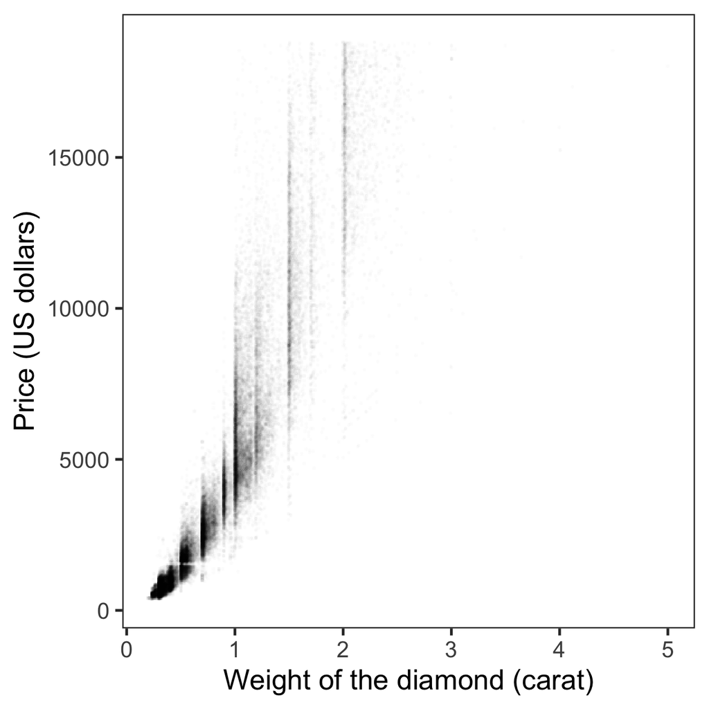

```r
# ... with marginal violin and labelled data points
gg + geom_scattermore(pointsize = 2, alpha = 0.02)
```

## Remarks

- [`scattermore`](https://github.com/exaexa/scattermore) does its magic by rendering the `geom_point` layer into a bitmap, while keeping all the other layers as they are, allowing you to create `pdf()` files that can be magnified without losing readability of the axes.
- [`scattermore`](https://github.com/exaexa/scattermore) provides two `ggplot2` layers: `geom_scattermore()` (which behaves mostly like `geom_point()`), and `geom_scattermost()` which avoids much of the overhead of a normal ggplot2 layer and thus is even more efficient, at the price that it has a slightly different interface and needs to get the data directly as the `xy` argument.
- An alternative, maybe even more convenient drop-in replacement for `geom_point()` and other `ggplot2` geoms that follows a similar strategy is `geom_point_rast()` from the [`ggrastr`](https://github.com/VPetukhov/ggrastr) package. This package also provides the `rasterize()` function that can take any existing `ggplot2` plot object and rasterize suitable layer in it. Compared to `scattermore`, `ggrastr` does not seem to be as fast and scale as well, though.